# Exploratory Data Analysis of Aadhaar Enrolment Data

# Plotting month vs total enrollment

```python
## monthly enrolment trend in bihar
df_uttarpradesh_monthly = df_uttarpradesh_cleaned.groupby('month')[['age_0_5','age_5_17','age_18_greater']].sum()
df_uttarpradesh_monthly['total_enrollment'] = df_bihar_monthly['age_0_5'] + df_uttarpradesh_monthly['age_5_17'] + df_uttarpradesh_monthly['age_18_greater']
```

```python
df_uttarpradesh_monthly.sort_values("total_enrollment",ascending=False).reset_index()
```

|  | month | age_0_5 | age_5_17 | age_18_greater | total_enrollment |
| --- | --- | --- | --- | --- | --- |
| 0 | 09 | 126150 | 132594 | 2335 | 197869 |
| 1 | 11 | 98391 | 77584 | 2402 | 124558 |
| 2 | 10 | 65951 | 60924 | 2120 | 106734 |
| 3 | 07 | 73166 | 81078 | 3622 | 103708 |
| 4 | 12 | 66126 | 46876 | 1402 | 90501 |
| 5 | 06 | 21109 | 26080 | 1564 | 43804 |
| 6 | 04 | 32513 | 23189 | 2201 | 37941 |
| 7 | 05 | 26928 | 21554 | 1379 | 36184 |
| 8 | 03 | 1393 | 3326 | 674 | 4516 |

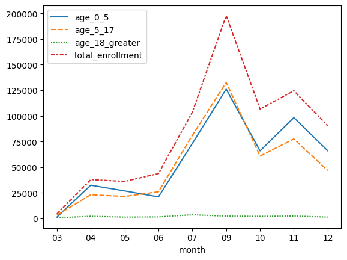

```python
sns.lineplot(data=df_uttarpradesh_monthly)
```

# Top 10 Districts by Enrollment

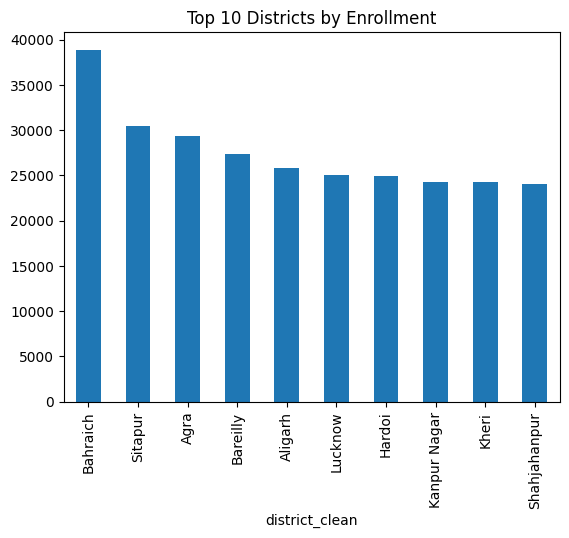

```python
top_districts_UP = df.groupby('district_clean')['total_enrollment'] \
                  .sum().sort_values(ascending=False).head(10)

top_districts_UP.plot(kind='bar')
plt.title('Top 10 Districts by Enrollment')
plt.show()
```

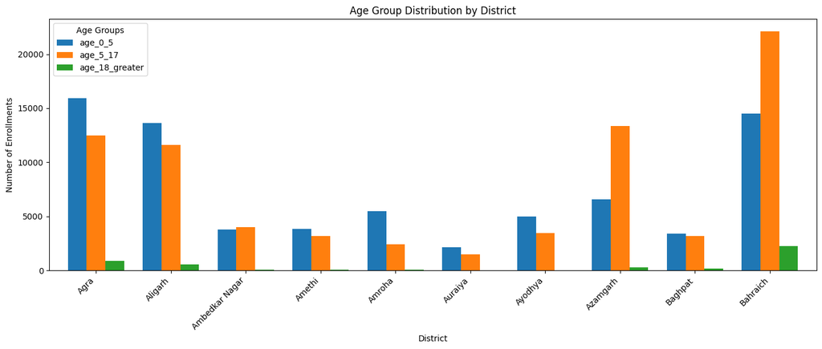

```python
import matplotlib.pyplot as plt

district_age_UP = df.groupby('district_clean')[
    ['age_0_5','age_5_17','age_18_greater']
].sum().head(10)

ax = district_age_UP.plot(
    kind='bar',
    stacked=False,      # important → no overlap
    figsize=(14,6),
    width=0.75
)

plt.title('Age Group Distribution by District')
plt.xlabel('District')
plt.ylabel('Number of Enrollments')
plt.xticks(rotation=45, ha='right')
plt.legend(title='Age Groups')
plt.tight_layout()
plt.show()
```

# 📊 Enrollment Variability Across Districts

This bar chart highlights the top 10 districts with the highest standard  
deviation in total enrollment, indicating significant variability over time. High volatility suggests  
inconsistent enrollment patterns, possibly due to seasonal drives, migration, or  
administrative factors.

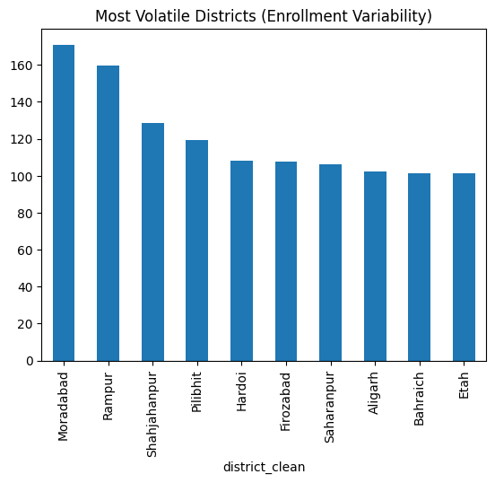

```python
district_std_UP = df.groupby('district_clean')['total_enrollment'].std()

district_std_UP.sort_values(ascending=False).head(10).plot(kind='bar')
plt.title('Most Volatile Districts (Enrollment Variability)')
plt.show()
```

# 📌 District-wise Enrollment Ranking Analysis

**This analysis ranks districts based on their total Aadhaar enrollment over the entire study period.**

```python
district_rank_UP = df.groupby('district_clean')['total_enrollment'].sum() \
                  .rank(ascending=False)

district_rank_UP.sort_values().head(10)
```

```
district_clean
Bahraich         1.0
Sitapur          2.0
Agra             3.0
Bareilly         4.0
Aligarh          5.0
Lucknow          6.0
Hardoi           7.0
Kanpur Nagar     8.0
Kheri            9.0
Shahjahanpur    10.0
Name: total_enrollment, dtype: float64
```

We performed univariate,  
bivariate, and multivariate analysis to study  
enrollment distribution across states, districts, and age groups.  
Advanced analysis included district-level volatility, age composition,  
time-based trends, and flag-based segmentation to uncover hidden patterns.

# Madhya Pradesh

```python
# Extracting rows where state is Madhya Pradesh
df_madhyapradesh= df[df['state_clean']=='Madhya Pradesh']
```

```python
# Total unique districts in Madhya Pradesh
df_madhyapradesh['district'].nunique()
```

```
61
```

```python
# Same District have more than one spelling so we have to map them
df_madhyapradesh['district'].unique()
```

```
array(['Bhind', 'Gwalior', 'Katni', 'Ashok Nagar', 'Betul', 'Guna',
       'Khargone', 'Chhatarpur', 'Morena', 'Dhar', 'Jabalpur', 'Barwani',
       'Shivpuri', 'Raisen', 'Jhabua', 'Indore', 'Bhopal', 'Datia',
       'Sagar', 'Sheopur', 'Vidisha', 'Burhanpur', 'Panna', 'Khandwa',
       'Satna', 'Alirajpur', 'Dewas', 'Ashoknagar', 'Balaghat',
       'East Nimar', 'Sehore', 'Narsinghpur', 'Hoshangabad', 'Agar Malwa',
       'Anuppur', 'Chhindwara', 'Damoh', 'Dindori', 'Harda', 'Maihar',
       'Mandla', 'Mandsaur', 'Narmadapuram', 'Narsimhapur', 'Neemuch',
       'Niwari', 'Rajgarh', 'Ratlam', 'Rewa', 'Seoni', 'Shahdol',
       'Shajapur', 'Sidhi', 'Singrauli', 'Tikamgarh', 'Ujjain',
       'West Nimar', 'Harda *', 'Mauganj', 'Umaria', 'Pandhurna'],
      dtype=object)
```

# Mapping District

```python
import pandas as pd
import re

def clean_name(x):
    if pd.isna(x):
        return x
    x = str(x).lower()
    x = re.sub(r'[^a-z]', '', x)
    x = re.sub(r'\s+',' ', x).strip()
    return x
```

```python
# District mapping Madhya Pradesh
mp_district_standard_map = {
    "ashok nagar": "Ashoknagar",
    "ashoknagar": "Ashoknagar",

    "east nimar": "Khandwa",
    "west nimar": "Khargone",

    "hoshangabad": "Narmadapuram",
    "narmadapuram": "Narmadapuram",

    "narsimhapur": "Narsinghpur",
    "narsinghpur": "Narsinghpur",

    "harda *": "Harda",
    "harda": "Harda",

    "mauganj": "Mauganj",
    "pandhurna": "Pandhurna"
}
```

```python
df['district_clean'] = (
    df['district']
    .apply(clean_name)
    .map(mp_district_standard_map)
    .fillna(df_madhyapradesh['district'])

)
```

```python
## Remaining unmapped
df_madhyapradesh[df_madhyapradesh['district_clean'].isna()]['district'].unique()
# count check
df_madhyapradesh['district_clean'].nunique()
```

```
0
```

```python
df_madhyapradesh = df[df['state_clean']=='Madhya Pradesh']
df_madhyapradesh
```

|  | date | state | district | pincode | age_0_5 | age_5_17 | age_18_greater | year | month | month_name | state_clean | total_enrollment | district_clean |
| --- | --- | --- | --- | --- | --- | --- | --- | --- | --- | --- | --- | --- | --- |
| 25 | 2025-03-09 | Madhya Pradesh | Bhind | 477116 | 37 | 18 | 11 | 2025 | 3 | Mar | Madhya Pradesh | 66 | Bhind |
| 26 | 2025-03-09 | Madhya Pradesh | Gwalior | 475110 | 42 | 14 | 14 | 2025 | 3 | Mar | Madhya Pradesh | 70 | Gwalior |
| 27 | 2025-03-09 | Madhya Pradesh | Katni | 483501 | 53 | 42 | 11 | 2025 | 3 | Mar | Madhya Pradesh | 106 | Katni |
| 76 | 2025-03-20 | Madhya Pradesh | Gwalior | 474001 | 73 | 25 | 18 | 2025 | 3 | Mar | Madhya Pradesh | 116 | Gwalior |
| 125 | 2025-03-23 | Madhya Pradesh | Gwalior | 474001 | 10 | 21 | 16 | 2025 | 3 | Mar | Madhya Pradesh | 47 | Gwalior |
| ... | ... | ... | ... | ... | ... | ... | ... | ... | ... | ... | ... | ... | ... |
| 1004141 | 2025-12-31 | Madhya Pradesh | Umaria | 484661 | 66 | 23 | 0 | 2025 | 12 | Dec | Madhya Pradesh | 89 | Umaria |
| 1004142 | 2025-12-31 | Madhya Pradesh | Umaria | 486661 | 2 | 0 | 0 | 2025 | 12 | Dec | Madhya Pradesh | 2 | Umaria |
| 1004143 | 2025-12-31 | Madhya Pradesh | Vidisha | 464001 | 32 | 6 | 0 | 2025 | 12 | Dec | Madhya Pradesh | 38 | Vidisha |
| 1004144 | 2025-12-31 | Madhya Pradesh | Vidisha | 464220 | 7 | 3 | 0 | 2025 | 12 | Dec | Madhya Pradesh | 10 | Vidisha |
| 1004145 | 2025-12-31 | Madhya Pradesh | West Nimar | 451111 | 2 | 1 | 0 | 2025 | 12 | Dec | Madhya Pradesh | 3 | West Nimar |

49562 rows × 13 columns

```python
# Check Madhya Pradesh-specific unmapped districts
df_madhyapradesh_unmapped = df_madhyapradesh[df_madhyapradesh['district_clean'].isna()]
print(f"Unmapped Madhya Pradesh districts count: {len(df_madhyapradesh_unmapped)}")
df_madhyapradesh_unmapped['district'].unique()
```

```
Unmapped Madhya Pradesh districts count: 0
```

```
array([], dtype=object)
```

```python
# Final unique districts in Madhya Pradesh after cleaning
df_madhyapradesh['district_clean'].unique()
```

```
array(['Bhind', 'Gwalior', 'Katni', 'Ashoknagar', 'Betul', 'Guna',
       'Khargone', 'Chhatarpur', 'Morena', 'Dhar', 'Jabalpur', 'Barwani',
       'Shivpuri', 'Raisen', 'Jhabua', 'Indore', 'Bhopal', 'Datia',
       'Sagar', 'Sheopur', 'Vidisha', 'Burhanpur', 'Panna', 'Khandwa',
       'Satna', 'Alirajpur', 'Dewas', 'Balaghat', 'East Nimar', 'Sehore',
       'Narsinghpur', 'Narmadapuram', 'Agar Malwa', 'Anuppur',
       'Chhindwara', 'Damoh', 'Dindori', 'Harda', 'Maihar', 'Mandla',
       'Mandsaur', 'Neemuch', 'Niwari', 'Rajgarh', 'Ratlam', 'Rewa',
       'Seoni', 'Shahdol', 'Shajapur', 'Sidhi', 'Singrauli', 'Tikamgarh',
       'Ujjain', 'West Nimar', 'Mauganj', 'Umaria', 'Pandhurna'],
      dtype=object)
```

```python
# Total unique districts in Madhya Pradesh after cleaning
df_madhyapradesh['district_clean'].nunique()
```

```
57
```

```python
# unique pincodes in Madhya Pradesh
df_madhyapradesh['pincode'].nunique()
```

```
787
```

```python
# Check unique pincodes per district in Madhya Pradesh
pincode_check = df_madhyapradesh.groupby('district_clean')['pincode'].nunique().reset_index(name='unique_pincodes')
pincode_check
```

|  | district_clean | unique_pincodes |
| --- | --- | --- |
| 0 | Agar Malwa | 6 |
| 1 | Alirajpur | 10 |
| 2 | Anuppur | 20 |
| 3 | Ashoknagar | 10 |
| 4 | Balaghat | 24 |
| 5 | Barwani | 11 |
| 6 | Betul | 21 |
| 7 | Bhind | 20 |
| 8 | Bhopal | 38 |
| 9 | Burhanpur | 5 |
| 10 | Chhatarpur | 20 |
| 11 | Chhindwara | 27 |
| 12 | Damoh | 14 |
| 13 | Datia | 9 |
| 14 | Dewas | 18 |
| 15 | Dhar | 23 |
| 16 | Dindori | 9 |
| 17 | East Nimar | 20 |
| 18 | Guna | 20 |
| 19 | Gwalior | 21 |
| 20 | Harda | 6 |
| 21 | Indore | 31 |
| 22 | Jabalpur | 27 |
| 23 | Jhabua | 14 |
| 24 | Katni | 17 |
| 25 | Khandwa | 16 |
| 26 | Khargone | 20 |
| 27 | Maihar | 8 |
| 28 | Mandla | 17 |
| 29 | Mandsaur | 20 |
| 30 | Mauganj | 9 |
| 31 | Morena | 12 |
| 32 | Narmadapuram | 20 |
| 33 | Narsinghpur | 16 |
| 34 | Neemuch | 15 |
| 35 | Niwari | 9 |
| 36 | Pandhurna | 8 |
| 37 | Panna | 15 |
| 38 | Raisen | 20 |
| 39 | Rajgarh | 15 |
| 40 | Ratlam | 14 |
| 41 | Rewa | 30 |
| 42 | Sagar | 28 |
| 43 | Satna | 26 |
| 44 | Sehore | 18 |
| 45 | Seoni | 17 |
| 46 | Shahdol | 23 |
| 47 | Shajapur | 23 |
| 48 | Sheopur | 5 |
| 49 | Shivpuri | 21 |
| 50 | Sidhi | 12 |
| 51 | Singrauli | 12 |
| 52 | Tikamgarh | 18 |
| 53 | Ujjain | 23 |
| 54 | Umaria | 10 |
| 55 | Vidisha | 13 |
| 56 | West Nimar | 20 |

```python
# Pincode associated with multiple districts in Madhya Pradesh
pin_district_count = (
    df_madhyapradesh.groupby('pincode')['district_clean']
    .nunique()
    .reset_index(name='district_count')
)
```

```python
pin_district_count
```

|  | pincode | district_count |
| --- | --- | --- |
| 0 | 450001 | 2 |
| 1 | 450051 | 2 |
| 2 | 450110 | 2 |
| 3 | 450112 | 2 |
| 4 | 450114 | 2 |
| ... | ... | ... |
| 782 | 488441 | 1 |
| 783 | 488442 | 1 |
| 784 | 488443 | 1 |
| 785 | 488446 | 1 |
| 786 | 488448 | 1 |

787 rows × 2 columns

```python
# Extract problematic pincodes (associated with >1 district)
problem_pins = pin_district_count[
    pin_district_count['district_count'] > 1
]
```

```python
problem_pins
```

|  | pincode | district_count |
| --- | --- | --- |
| 0 | 450001 | 2 |
| 1 | 450051 | 2 |
| 2 | 450110 | 2 |
| 3 | 450112 | 2 |
| 4 | 450114 | 2 |
| ... | ... | ... |
| 748 | 486882 | 2 |
| 749 | 486884 | 2 |
| 751 | 486886 | 4 |
| 754 | 486889 | 2 |
| 755 | 486890 | 2 |

163 rows × 2 columns

```python
# Get all records with problematic pincodes(flagged records)
df_flagged = df_madhyapradesh.merge(
    problem_pins[['pincode']],
    on='pincode',
    how='inner'
)
```

```python
df_flagged
```

|  | date | state | district | pincode | age_0_5 | age_5_17 | age_18_greater | year | month | month_name | state_clean | total_enrollment | district_clean |
| --- | --- | --- | --- | --- | --- | --- | --- | --- | --- | --- | --- | --- | --- |
| 0 | 2025-03-09 | Madhya Pradesh | Gwalior | 475110 | 42 | 14 | 14 | 2025 | 3 | Mar | Madhya Pradesh | 70 | Gwalior |
| 1 | 2025-03-27 | Madhya Pradesh | Gwalior | 475110 | 54 | 26 | 14 | 2025 | 3 | Mar | Madhya Pradesh | 94 | Gwalior |
| 2 | 2025-04-01 | Madhya Pradesh | Ashok Nagar | 473335 | 125 | 29 | 22 | 2025 | 4 | Apr | Madhya Pradesh | 176 | Ashoknagar |
| 3 | 2025-04-01 | Madhya Pradesh | Ashok Nagar | 473443 | 141 | 57 | 15 | 2025 | 4 | Apr | Madhya Pradesh | 213 | Ashoknagar |
| 4 | 2025-04-01 | Madhya Pradesh | Guna | 473101 | 110 | 32 | 11 | 2025 | 4 | Apr | Madhya Pradesh | 153 | Guna |
| ... | ... | ... | ... | ... | ... | ... | ... | ... | ... | ... | ... | ... | ... |
| 13596 | 2025-12-31 | Madhya Pradesh | Tikamgarh | 472246 | 6 | 5 | 0 | 2025 | 12 | Dec | Madhya Pradesh | 11 | Tikamgarh |
| 13597 | 2025-12-31 | Madhya Pradesh | Umaria | 484661 | 66 | 23 | 0 | 2025 | 12 | Dec | Madhya Pradesh | 89 | Umaria |
| 13598 | 2025-12-31 | Madhya Pradesh | Umaria | 486661 | 2 | 0 | 0 | 2025 | 12 | Dec | Madhya Pradesh | 2 | Umaria |
| 13599 | 2025-12-31 | Madhya Pradesh | Vidisha | 464001 | 32 | 6 | 0 | 2025 | 12 | Dec | Madhya Pradesh | 38 | Vidisha |
| 13600 | 2025-12-31 | Madhya Pradesh | West Nimar | 451111 | 2 | 1 | 0 | 2025 | 12 | Dec | Madhya Pradesh | 3 | West Nimar |

13601 rows × 13 columns

```python
# Summary of flagged records by district and pincode(for review)
flagged_pincode=df_flagged.groupby(['district_clean','pincode'])[['age_0_5','age_5_17','age_18_greater']].sum().reset_index()
# flagged_pincode.to_excel('flagged_pincode_domain_mp.xlsx')
```

```python
# Add total enrollment column to flagged_pincode
flagged_pincode['total_enrollment']=flagged_pincode['age_0_5']+flagged_pincode['age_5_17']+flagged_pincode['age_18_greater']
flagged_pincode
```

|  | district_clean | pincode | age_0_5 | age_5_17 | age_18_greater | total_enrollment |
| --- | --- | --- | --- | --- | --- | --- |
| 0 | Agar Malwa | 465230 | 254 | 54 | 3 | 311 |
| 1 | Agar Malwa | 465441 | 618 | 136 | 16 | 770 |
| 2 | Agar Malwa | 465445 | 369 | 65 | 0 | 434 |
| 3 | Agar Malwa | 465447 | 389 | 81 | 2 | 472 |
| 4 | Agar Malwa | 465550 | 205 | 47 | 7 | 259 |
| ... | ... | ... | ... | ... | ... | ... |
| 345 | West Nimar | 451335 | 17 | 8 | 0 | 25 |
| 346 | West Nimar | 451440 | 45 | 6 | 0 | 51 |
| 347 | West Nimar | 451441 | 76 | 33 | 0 | 109 |
| 348 | West Nimar | 451442 | 27 | 9 | 1 | 37 |
| 349 | West Nimar | 451660 | 13 | 1 | 0 | 14 |

350 rows × 6 columns

```python
idx = flagged_pincode.groupby('pincode')['total_enrollment'].idxmax()
df_filtered = flagged_pincode.loc[idx]
df_filtered
```

|  | district_clean | pincode | age_0_5 | age_5_17 | age_18_greater | total_enrollment |
| --- | --- | --- | --- | --- | --- | --- |
| 141 | Khandwa | 450001 | 1082 | 301 | 17 | 1400 |
| 142 | Khandwa | 450051 | 45 | 17 | 1 | 63 |
| 143 | Khandwa | 450110 | 52 | 23 | 0 | 75 |
| 144 | Khandwa | 450112 | 107 | 61 | 5 | 173 |
| 84 | East Nimar | 450114 | 143 | 103 | 2 | 248 |
| ... | ... | ... | ... | ... | ... | ... |
| 303 | Singrauli | 486882 | 988 | 130 | 4 | 1122 |
| 297 | Sidhi | 486884 | 47 | 6 | 0 | 53 |
| 305 | Singrauli | 486886 | 2124 | 337 | 3 | 2464 |
| 306 | Singrauli | 486889 | 220 | 65 | 6 | 291 |
| 300 | Sidhi | 486890 | 67 | 21 | 0 | 88 |

163 rows × 6 columns

```python
# Creating a flag for pincodes associated with multiple districts
df_madhyapradesh['pin_multi_district_flag']=(
    df_madhyapradesh.groupby('pincode')['district_clean']
    .transform('nunique')>1
)
```

```python
# Creating a flag for pincodes associated with multiple districts
pin_district_map= (
    df_madhyapradesh[df_madhyapradesh['pin_multi_district_flag']]
    .groupby('pincode')['district_clean']  # noqa: SC100
    .unique()
    .reset_index()
)
```

```python
## monthly enrolment check
df_madhyapradesh['month'] = df_madhyapradesh['date'].dt.month.astype(str).str.zfill(2)
df_madhyapradesh
```

|  | date | state | district | pincode | age_0_5 | age_5_17 | age_18_greater | year | month | month_name | state_clean | total_enrollment | district_clean | pin_multi_district_flag |
| --- | --- | --- | --- | --- | --- | --- | --- | --- | --- | --- | --- | --- | --- | --- |
| 25 | 2025-03-09 | Madhya Pradesh | Bhind | 477116 | 37 | 18 | 11 | 2025 | 03 | Mar | Madhya Pradesh | 66 | Bhind | False |
| 26 | 2025-03-09 | Madhya Pradesh | Gwalior | 475110 | 42 | 14 | 14 | 2025 | 03 | Mar | Madhya Pradesh | 70 | Gwalior | True |
| 27 | 2025-03-09 | Madhya Pradesh | Katni | 483501 | 53 | 42 | 11 | 2025 | 03 | Mar | Madhya Pradesh | 106 | Katni | False |
| 76 | 2025-03-20 | Madhya Pradesh | Gwalior | 474001 | 73 | 25 | 18 | 2025 | 03 | Mar | Madhya Pradesh | 116 | Gwalior | False |
| 125 | 2025-03-23 | Madhya Pradesh | Gwalior | 474001 | 10 | 21 | 16 | 2025 | 03 | Mar | Madhya Pradesh | 47 | Gwalior | False |
| ... | ... | ... | ... | ... | ... | ... | ... | ... | ... | ... | ... | ... | ... | ... |
| 1004141 | 2025-12-31 | Madhya Pradesh | Umaria | 484661 | 66 | 23 | 0 | 2025 | 12 | Dec | Madhya Pradesh | 89 | Umaria | True |
| 1004142 | 2025-12-31 | Madhya Pradesh | Umaria | 486661 | 2 | 0 | 0 | 2025 | 12 | Dec | Madhya Pradesh | 2 | Umaria | True |
| 1004143 | 2025-12-31 | Madhya Pradesh | Vidisha | 464001 | 32 | 6 | 0 | 2025 | 12 | Dec | Madhya Pradesh | 38 | Vidisha | True |
| 1004144 | 2025-12-31 | Madhya Pradesh | Vidisha | 464220 | 7 | 3 | 0 | 2025 | 12 | Dec | Madhya Pradesh | 10 | Vidisha | False |
| 1004145 | 2025-12-31 | Madhya Pradesh | West Nimar | 451111 | 2 | 1 | 0 | 2025 | 12 | Dec | Madhya Pradesh | 3 | West Nimar | True |

49562 rows × 14 columns

```python
# Dropping Date District and state as we have District clean State clean
df_madhyapradesh_cleaned=df_madhyapradesh.drop(columns=['date','district','state'], axis=1)
df_madhyapradesh_cleaned
```

|  | pincode | age_0_5 | age_5_17 | age_18_greater | year | month | month_name | state_clean | total_enrollment | district_clean | pin_multi_district_flag |
| --- | --- | --- | --- | --- | --- | --- | --- | --- | --- | --- | --- |
| 25 | 477116 | 37 | 18 | 11 | 2025 | 03 | Mar | Madhya Pradesh | 66 | Bhind | False |
| 26 | 475110 | 42 | 14 | 14 | 2025 | 03 | Mar | Madhya Pradesh | 70 | Gwalior | True |
| 27 | 483501 | 53 | 42 | 11 | 2025 | 03 | Mar | Madhya Pradesh | 106 | Katni | False |
| 76 | 474001 | 73 | 25 | 18 | 2025 | 03 | Mar | Madhya Pradesh | 116 | Gwalior | False |
| 125 | 474001 | 10 | 21 | 16 | 2025 | 03 | Mar | Madhya Pradesh | 47 | Gwalior | False |
| ... | ... | ... | ... | ... | ... | ... | ... | ... | ... | ... | ... |
| 1004141 | 484661 | 66 | 23 | 0 | 2025 | 12 | Dec | Madhya Pradesh | 89 | Umaria | True |
| 1004142 | 486661 | 2 | 0 | 0 | 2025 | 12 | Dec | Madhya Pradesh | 2 | Umaria | True |
| 1004143 | 464001 | 32 | 6 | 0 | 2025 | 12 | Dec | Madhya Pradesh | 38 | Vidisha | True |
| 1004144 | 464220 | 7 | 3 | 0 | 2025 | 12 | Dec | Madhya Pradesh | 10 | Vidisha | False |
| 1004145 | 451111 | 2 | 1 | 0 | 2025 | 12 | Dec | Madhya Pradesh | 3 | West Nimar | True |

49562 rows × 11 columns

# Flagged vs unflagged pincodes

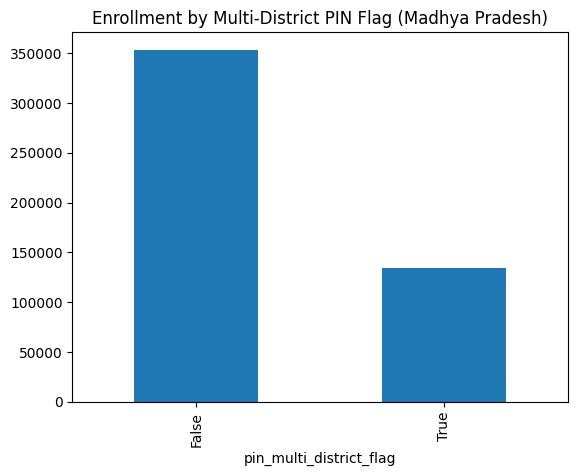

```python
df_madhyapradesh.groupby('pin_multi_district_flag')['total_enrollment'].sum().plot(
    kind='bar'
)
plt.title('Enrollment by Multi-District PIN Flag (Madhya Pradesh)')
plt.show()
```

```python
# Aggregate Madhya Pradesh enrollment data at the district level by summing enrollments
# across different age groups (0–5, 5–17, and 18+).
df_madhyapradesh_dist_level = df_madhyapradesh_cleaned.groupby('district_clean')[
    ['age_0_5', 'age_5_17', 'age_18_greater']
].sum()

# Compute total enrollment for each district by adding all age-group enrollments
df_madhyapradesh_dist_level['total_enrollment'] = (
    df_madhyapradesh_dist_level['age_0_5'] +
    df_madhyapradesh_dist_level['age_5_17'] +
    df_madhyapradesh_dist_level['age_18_greater']
)
```

```python
df_madhyapradesh_dist_level.shape
```

```
(57, 4)
```

```python
df_madhyapradesh_dist_level
```

| district_clean | age_0_5 | age_5_17 | age_18_greater | total_enrollment |
| --- | --- | --- | --- | --- |
| Agar Malwa | 2079 | 418 | 29 | 2526 |
| Alirajpur | 3184 | 3359 | 369 | 6912 |
| Anuppur | 2824 | 344 | 13 | 3181 |
| Ashoknagar | 5300 | 2600 | 261 | 8161 |
| Balaghat | 6104 | 534 | 28 | 6666 |
| Barwani | 12794 | 8352 | 667 | 21813 |
| Betul | 6754 | 1202 | 126 | 8082 |
| Bhind | 8421 | 4821 | 635 | 13877 |
| Bhopal | 11063 | 1430 | 154 | 12647 |
| Burhanpur | 6542 | 2759 | 388 | 9689 |
| Chhatarpur | 11372 | 5925 | 367 | 17664 |
| Chhindwara | 8201 | 618 | 47 | 8866 |
| Damoh | 4957 | 923 | 46 | 5926 |
| Datia | 3972 | 1794 | 43 | 5809 |
| Dewas | 8333 | 1943 | 91 | 10367 |
| Dhar | 8607 | 3517 | 425 | 12549 |
| Dindori | 2370 | 247 | 1 | 2618 |
| East Nimar | 2293 | 1482 | 21 | 3796 |
| Guna | 7410 | 2224 | 65 | 9699 |
| Gwalior | 11981 | 5566 | 823 | 18370 |
| Harda | 2198 | 487 | 18 | 2703 |
| Indore | 16493 | 4963 | 602 | 22058 |
| Jabalpur | 10578 | 1704 | 101 | 12383 |
| Jhabua | 6552 | 6556 | 328 | 13436 |
| Katni | 8305 | 2365 | 116 | 10786 |
| Khandwa | 3166 | 1213 | 82 | 4461 |
| Khargone | 9781 | 4637 | 504 | 14922 |
| Maihar | 362 | 19 | 19 | 400 |
| Mandla | 4595 | 259 | 5 | 4859 |
| Mandsaur | 7321 | 803 | 24 | 8148 |
| Mauganj | 365 | 57 | 1 | 423 |
| Morena | 14005 | 7605 | 658 | 22268 |
| Narmadapuram | 5696 | 903 | 41 | 6640 |
| Narsinghpur | 4779 | 1440 | 91 | 6310 |
| Neemuch | 4134 | 758 | 17 | 4909 |
| Niwari | 114 | 15 | 9 | 138 |
| Pandhurna | 66 | 4 | 28 | 98 |
| Panna | 6775 | 2397 | 128 | 9300 |
| Raisen | 6129 | 1219 | 122 | 7470 |
| Rajgarh | 6381 | 1535 | 34 | 7950 |
| Ratlam | 6376 | 1433 | 75 | 7884 |
| Rewa | 9199 | 1442 | 29 | 10670 |
| Sagar | 11373 | 1829 | 378 | 13580 |
| Satna | 11068 | 1908 | 128 | 13104 |
| Sehore | 5069 | 1292 | 54 | 6415 |
| Seoni | 5481 | 510 | 8 | 5999 |
| Shahdol | 4322 | 817 | 59 | 5198 |
| Shajapur | 5792 | 1030 | 18 | 6840 |
| Sheopur | 3740 | 3264 | 139 | 7143 |
| Shivpuri | 6979 | 4728 | 720 | 12427 |
| Sidhi | 5544 | 655 | 13 | 6212 |
| Singrauli | 5427 | 819 | 19 | 6265 |
| Tikamgarh | 5581 | 1521 | 28 | 7130 |
| Ujjain | 12249 | 1726 | 82 | 14057 |
| Umaria | 4225 | 890 | 24 | 5139 |
| Vidisha | 7855 | 2178 | 169 | 10202 |
| West Nimar | 608 | 133 | 6 | 747 |

```python
# Sorting District with total enrollment
df_madhyapradesh_dist_level.sort_values("total_enrollment",ascending=False).reset_index()
# df_madhyapradesh_dist_level.to_excel('madhyapradesh_district_level_enrolment.xlsx')
```

|  | district_clean | age_0_5 | age_5_17 | age_18_greater | total_enrollment |
| --- | --- | --- | --- | --- | --- |
| 0 | Morena | 14005 | 7605 | 658 | 22268 |
| 1 | Indore | 16493 | 4963 | 602 | 22058 |
| 2 | Barwani | 12794 | 8352 | 667 | 21813 |
| 3 | Gwalior | 11981 | 5566 | 823 | 18370 |
| 4 | Chhatarpur | 11372 | 5925 | 367 | 17664 |
| 5 | Khargone | 9781 | 4637 | 504 | 14922 |
| 6 | Ujjain | 12249 | 1726 | 82 | 14057 |
| 7 | Bhind | 8421 | 4821 | 635 | 13877 |
| 8 | Sagar | 11373 | 1829 | 378 | 13580 |
| 9 | Jhabua | 6552 | 6556 | 328 | 13436 |
| 10 | Satna | 11068 | 1908 | 128 | 13104 |
| 11 | Bhopal | 11063 | 1430 | 154 | 12647 |
| 12 | Dhar | 8607 | 3517 | 425 | 12549 |
| 13 | Shivpuri | 6979 | 4728 | 720 | 12427 |
| 14 | Jabalpur | 10578 | 1704 | 101 | 12383 |
| 15 | Katni | 8305 | 2365 | 116 | 10786 |
| 16 | Rewa | 9199 | 1442 | 29 | 10670 |
| 17 | Dewas | 8333 | 1943 | 91 | 10367 |
| 18 | Vidisha | 7855 | 2178 | 169 | 10202 |
| 19 | Guna | 7410 | 2224 | 65 | 9699 |
| 20 | Burhanpur | 6542 | 2759 | 388 | 9689 |
| 21 | Panna | 6775 | 2397 | 128 | 9300 |
| 22 | Chhindwara | 8201 | 618 | 47 | 8866 |
| 23 | Ashoknagar | 5300 | 2600 | 261 | 8161 |
| 24 | Mandsaur | 7321 | 803 | 24 | 8148 |
| 25 | Betul | 6754 | 1202 | 126 | 8082 |
| 26 | Rajgarh | 6381 | 1535 | 34 | 7950 |
| 27 | Ratlam | 6376 | 1433 | 75 | 7884 |
| 28 | Raisen | 6129 | 1219 | 122 | 7470 |
| 29 | Sheopur | 3740 | 3264 | 139 | 7143 |
| 30 | Tikamgarh | 5581 | 1521 | 28 | 7130 |
| 31 | Alirajpur | 3184 | 3359 | 369 | 6912 |
| 32 | Shajapur | 5792 | 1030 | 18 | 6840 |
| 33 | Balaghat | 6104 | 534 | 28 | 6666 |
| 34 | Narmadapuram | 5696 | 903 | 41 | 6640 |
| 35 | Sehore | 5069 | 1292 | 54 | 6415 |
| 36 | Narsinghpur | 4779 | 1440 | 91 | 6310 |
| 37 | Singrauli | 5427 | 819 | 19 | 6265 |
| 38 | Sidhi | 5544 | 655 | 13 | 6212 |
| 39 | Seoni | 5481 | 510 | 8 | 5999 |
| 40 | Damoh | 4957 | 923 | 46 | 5926 |
| 41 | Datia | 3972 | 1794 | 43 | 5809 |
| 42 | Shahdol | 4322 | 817 | 59 | 5198 |
| 43 | Umaria | 4225 | 890 | 24 | 5139 |
| 44 | Neemuch | 4134 | 758 | 17 | 4909 |
| 45 | Mandla | 4595 | 259 | 5 | 4859 |
| 46 | Khandwa | 3166 | 1213 | 82 | 4461 |
| 47 | East Nimar | 2293 | 1482 | 21 | 3796 |
| 48 | Anuppur | 2824 | 344 | 13 | 3181 |
| 49 | Harda | 2198 | 487 | 18 | 2703 |
| 50 | Dindori | 2370 | 247 | 1 | 2618 |
| 51 | Agar Malwa | 2079 | 418 | 29 | 2526 |
| 52 | West Nimar | 608 | 133 | 6 | 747 |
| 53 | Mauganj | 365 | 57 | 1 | 423 |
| 54 | Maihar | 362 | 19 | 19 | 400 |
| 55 | Niwari | 114 | 15 | 9 | 138 |
| 56 | Pandhurna | 66 | 4 | 28 | 98 |